# Tasa de abandono. Comparativa de modelos

Samuel LP

# 1 LIBRERÍAS Y DATOS

```r
suppressPackageStartupMessages({
  library(tidyverse)
  library(caret)

  library(parallel)
  library(doParallel)
  library(kableExtra)
  library(formattable)
  library(gridExtra)
  library(ggpubr)
  library(pROC)




 })
```

Funciones:

```r
source('Funciones/func_resultados_modelos.R')
```

Datos:

```r
data <- read.csv("data_preproc/data_scale.csv", stringsAsFactors = TRUE)
data_balanced <- read.csv("data_preproc/data_balanced_scale.csv", stringsAsFactors = TRUE)
```

Muestras:

```r
set.seed(2876)

# Índice de partición
Indice_Particion <- createDataPartition(data$y, p = 0.80, list = FALSE)

# Muestras de entrenamiento y test para redes bayesianas

train <- data[ Indice_Particion, ]
val <- data[ -Indice_Particion, ]
```

```r
set.seed(2877)

# Índice de partición
Indice_Particion <- createDataPartition(data_balanced$y, p = 0.80, list = FALSE)

# Muestras de entrenamiento y test para gradient boosting
train_balanced <- data_balanced[ Indice_Particion, ]
val_balanced <- data_balanced[ -Indice_Particion, ]
```

Modelos:

```r
# datos sin balancear

rf_train <- readRDS("Resultados_Modelos/rf_train.RDS")
rl_train <- readRDS("Resultados_Modelos/rl_train.RDS")
nnet_train <- readRDS("Resultados_Modelos/nnet_train.RDS")
C5_train <- readRDS("Resultados_Modelos/C5_train.RDS")

# datos balanceados

rf_train_bal <- readRDS("Resultados_Modelos/rf_train_bal.RDS")
rl_train_bal <- readRDS("Resultados_Modelos/rl_train_bal.RDS")
nnet_train_bal <- readRDS("Resultados_Modelos/nnet_train_bal.RDS")
C5_train_bal <- readRDS("Resultados_Modelos/C5_train_bal.RDS")
```

# 2 IMPORTANCIA DE LAS VARIABLES

En cada modelo se ha visto la importancia de cada variable. Aquí se verá de forma global para facilitar la comparación.

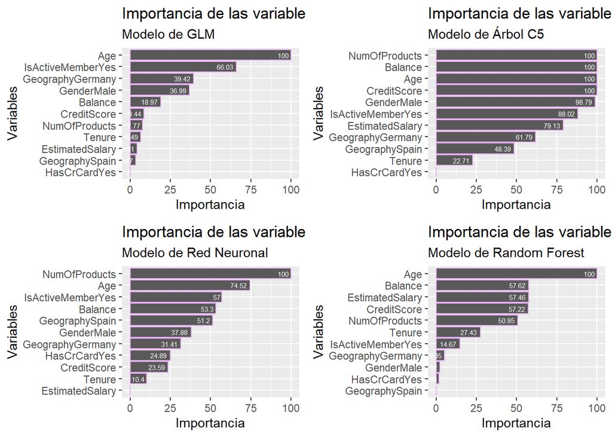

```r
# datos sin balancear

ggarrange(importancia_var(rl_train, "de GLM"),
importancia_var(C5_train, "de Árbol C5"),importancia_var(nnet_train, "de Red Neuronal"),importancia_var(rf_train, "de Random Forest"), ncol=2,nrow=2)
```

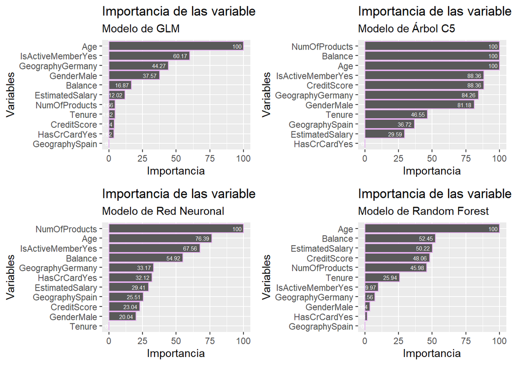

```r
# datos balanceados

ggarrange(importancia_var(rl_train_bal, "de GLM"),
importancia_var(C5_train_bal, "de Árbol C5"),importancia_var(nnet_train_bal, "de Red Neuronal"),importancia_var(rf_train_bal, "de Random Forest"), ncol=2,nrow=2)
```

# 3 COMPARATIVA DE MODELOS

Necesitamos la salida de la función resumen:

```r
resumen_rl <- resumen(rl_train,train, val)
resumen_rf <- resumen(rf_train,train, val)
resumen_nnet <- resumen(nnet_train, train, val)
resumen_C5 <- resumen(C5_train,train, val)

resumen_rl_bal <- resumen(rl_train_bal,train_balanced, val_balanced)
resumen_rf_bal <- resumen(rf_train_bal,train_balanced, val_balanced)
resumen_nnet_bal <- resumen(nnet_train_bal, train_balanced, val_balanced)
resumen_C5_bal <- resumen(C5_train_bal,train_balanced, val_balanced)
```

```r
Nombresmodelos <- c("RL", "RF", "MLP","C5")


DatosEnt_RL <- resumen_rl[1,]
DatosVal_RL <- resumen_rl[2,]
DatosEnt_RF <- resumen_rf[1,]
DatosVal_RF <- resumen_rf[2,]
DatosEnt_MLP <- resumen_nnet[1,]
DatosVal_MLP <- resumen_nnet[2,]
DatosEnt_C5 <- resumen_C5[1,]
DatosVal_C5 <- resumen_C5[2,]
```

```r
DatosEnt_RL_bal <- resumen_rl_bal[1,]
DatosVal_RL_bal <- resumen_rl_bal[2,]
DatosEnt_RF_bal <- resumen_rf_bal[1,]
DatosVal_RF_bal <- resumen_rf_bal[2,]
DatosEnt_MLP_bal <- resumen_nnet_bal[1,]
DatosVal_MLP_bal <- resumen_nnet_bal[2,]
DatosEnt_C5_bal <- resumen_C5_bal[1,]
DatosVal_C5_bal <- resumen_C5_bal[2,]
```

Se va a comparar los modelos usando la partición de entrenamiento y la partición de test. En ambos casos se ordenan resultados de mayor a menor AUC (puede elegirse otra métrica)

Con los datos sin balancear tenemos:

```r
DatosEntrenamiento <- rbind(DatosEnt_RL, DatosEnt_RF,DatosEnt_MLP, DatosVal_C5)


rownames(DatosEntrenamiento) <- Nombresmodelos

DatosEntrenamiento <-as.data.frame(DatosEntrenamiento)

DatosEntrenamiento %>% arrange(-AUC) %>%
    mutate(AUC = color_tile("white", "orange")(AUC),
    Accuracy = color_tile("white", "orange")(Accuracy),

    Kappa = color_tile("white", "orange")(Kappa),

    Sensitivity = color_tile("white", "orange")(Sensitivity),

    Specificity = color_tile("white", "orange")(Specificity)

  ) %>%
  kable(escape = F) %>%
  kable_styling("hover", full_width = F) %>%
  kable_styling("hover", full_width = F) %>%
  add_header_above(c(" ", "Comparación con la Muestra de Entrenamiento" = 7))
```

|  | Comparación con la Muestra de Entrenamiento AUC | Comparación con la Muestra de Entrenamiento Accuracy | Comparación con la Muestra de Entrenamiento Aciertos Clase SI | Comparación con la Muestra de Entrenamiento Aciertos Clase NO | Comparación con la Muestra de Entrenamiento Kappa | Comparación con la Muestra de Entrenamiento Sensitivity | Comparación con la Muestra de Entrenamiento Specificity |
| --- | --- | --- | --- | --- | --- | --- | --- |
| RF | 1.000 | 1.000 | 1.000 | 1.000 | 1.000 | 1.000 | 1.000 |
| MLP | 0.873 | 0.865 | 0.880 | 0.765 | 0.519 | 0.962 | 0.487 |
| C5 | 0.871 | 0.865 | 0.877 | 0.780 | 0.511 | 0.966 | 0.469 |
| RL | 0.764 | 0.811 | 0.827 | 0.602 | 0.233 | 0.964 | 0.213 |

```r
DatosValidación <- rbind(DatosVal_RL, DatosVal_RF,
                         DatosVal_MLP, DatosVal_C5)


rownames(DatosValidación) <- Nombresmodelos
DatosValidación <-as.data.frame(DatosValidación)

DatosValidación %>% arrange(-AUC) %>%
    mutate(AUC = color_tile("white", "orange")(AUC),
    Accuracy = color_tile("white", "orange")(Accuracy),

    Kappa = color_tile("white", "orange")(Kappa),

    Sensitivity = color_tile("white", "orange")(Sensitivity),

    Specificity = color_tile("white", "orange")(Specificity)

  ) %>%
  kable(escape = F) %>%
  kable_styling("hover", full_width = F) %>%
  add_header_above(c(" ", "Comparación con la Muestra de Validacion" = 7))
```

|  | Comparación con la Muestra de Validacion AUC | Comparación con la Muestra de Validacion Accuracy | Comparación con la Muestra de Validacion Aciertos Clase SI | Comparación con la Muestra de Validacion Aciertos Clase NO | Comparación con la Muestra de Validacion Kappa | Comparación con la Muestra de Validacion Sensitivity | Comparación con la Muestra de Validacion Specificity |
| --- | --- | --- | --- | --- | --- | --- | --- |
| MLP | 0.878 | 0.869 | 0.883 | 0.778 | 0.534 | 0.964 | 0.499 |
| C5 | 0.871 | 0.865 | 0.877 | 0.780 | 0.511 | 0.966 | 0.469 |
| RF | 0.867 | 0.859 | 0.875 | 0.747 | 0.494 | 0.960 | 0.464 |
| RL | 0.779 | 0.809 | 0.825 | 0.594 | 0.221 | 0.965 | 0.201 |

Con los datos balanceados:

```r
DatosEntrenamiento_bal <- rbind(DatosEnt_RL_bal, DatosEnt_RF_bal,DatosEnt_MLP_bal, DatosVal_C5_bal)


rownames(DatosEntrenamiento_bal) <- Nombresmodelos

DatosEntrenamiento_bal <-as.data.frame(DatosEntrenamiento_bal)

DatosEntrenamiento_bal %>% arrange(-AUC) %>%
    mutate(AUC = color_tile("white", "orange")(AUC),
    Accuracy = color_tile("white", "orange")(Accuracy),

    Kappa = color_tile("white", "orange")(Kappa),

    Sensitivity = color_tile("white", "orange")(Sensitivity),

    Specificity = color_tile("white", "orange")(Specificity)

  ) %>%
  kable(escape = F) %>%
  kable_styling("hover", full_width = F) %>%
  kable_styling("hover", full_width = F) %>%
  add_header_above(c(" ", "Comparación con la Muestra de Entrenamiento" = 7))
```

|  | Comparación con la Muestra de Entrenamiento AUC | Comparación con la Muestra de Entrenamiento Accuracy | Comparación con la Muestra de Entrenamiento Aciertos Clase SI | Comparación con la Muestra de Entrenamiento Aciertos Clase NO | Comparación con la Muestra de Entrenamiento Kappa | Comparación con la Muestra de Entrenamiento Sensitivity | Comparación con la Muestra de Entrenamiento Specificity |
| --- | --- | --- | --- | --- | --- | --- | --- |
| RF | 1.000 | 1.000 | 1.000 | 1.000 | 1.000 | 1.000 | 1.000 |
| MLP | 0.878 | 0.792 | 0.782 | 0.803 | 0.585 | 0.811 | 0.774 |
| C5 | 0.862 | 0.781 | 0.762 | 0.804 | 0.563 | 0.818 | 0.744 |
| RL | 0.769 | 0.704 | 0.702 | 0.708 | 0.409 | 0.712 | 0.697 |

```r
DatosValidación_bal <- rbind(DatosVal_RL_bal, DatosVal_RF_bal,
                         DatosVal_MLP_bal, DatosVal_C5_bal)


rownames(DatosValidación_bal) <- Nombresmodelos
DatosValidación_bal <-as.data.frame(DatosValidación_bal)

DatosValidación_bal %>% arrange(-AUC) %>%
    mutate(AUC = color_tile("white", "orange")(AUC),
    Accuracy = color_tile("white", "orange")(Accuracy),

    Kappa = color_tile("white", "orange")(Kappa),

    Sensitivity = color_tile("white", "orange")(Sensitivity),

    Specificity = color_tile("white", "orange")(Specificity)

  ) %>%
  kable(escape = F) %>%
  kable_styling("hover", full_width = F) %>%
  add_header_above(c(" ", "Comparación con la Muestra de Validacion" = 7))
```

|  | Comparación con la Muestra de Validacion AUC | Comparación con la Muestra de Validacion Accuracy | Comparación con la Muestra de Validacion Aciertos Clase SI | Comparación con la Muestra de Validacion Aciertos Clase NO | Comparación con la Muestra de Validacion Kappa | Comparación con la Muestra de Validacion Sensitivity | Comparación con la Muestra de Validacion Specificity |
| --- | --- | --- | --- | --- | --- | --- | --- |
| C5 | 0.862 | 0.781 | 0.762 | 0.804 | 0.563 | 0.818 | 0.744 |
| MLP | 0.857 | 0.768 | 0.757 | 0.779 | 0.536 | 0.789 | 0.747 |
| RF | 0.855 | 0.758 | 0.749 | 0.768 | 0.516 | 0.776 | 0.740 |
| RL | 0.779 | 0.714 | 0.710 | 0.718 | 0.428 | 0.722 | 0.705 |

Se puede comprobar que el modelo RF parece tener un problema de sobreajuste (métricas perfectas con los datos de entramiento). Las mejores opciones podrían serel árbol C5 y la red neuronal.

La mayor diferencia en el resultado con los datos balanceados y sin balancear es que la diferencia entre sensibilidad y especificidad es menor con los datos balanceados. Se sacrifica sensibilidad en el proceso.

Se está en un problema de churn y una alta sensibilidad ayudaría a detectar clientes que realmente abandonarán el banco. Pero si la especificidad es baja se está también identificando de forma incorrecta a clientes que no abandonarán el banco como si lo fueran a hacer (falsos positivos).

# 4 CONTRATES DE HIPÓTESIS

A continuación se va a estimar si los modelos son significativamente diferentes unos de otros. Se toman las medidas de precisión (accuracy), kappa, ROC, sensibilidad y especificidad

```r
modelos <- list(RL= rl_train, RF = rf_train,  MLP = nnet_train, C5 = C5_train)
```

```r
comp_modelos <- resamples(modelos)
comp_modelos
```

```
##
## Call:
## resamples.default(x = modelos)
##
## Models: RL, RF, MLP, C5
## Number of resamples: 5
## Performance metrics: Accuracy, Kappa, ROC, Sens, Spec
## Time estimates for: everything, final model fit
```

```r
summary(comp_modelos)
```

```
##
## Call:
## summary.resamples(object = comp_modelos)
##
## Models: RL, RF, MLP, C5
## Number of resamples: 5
##
## Accuracy
##          Min.   1st Qu.   Median      Mean  3rd Qu.     Max. NA's
## RL  0.8056250 0.8082448 0.808750 0.8105240 0.814375 0.815625    0
## RF  0.8575890 0.8593750 0.865000 0.8632678 0.865000 0.869375    0
## MLP 0.8507183 0.8562500 0.859375 0.8597687 0.865625 0.866875    0
## C5  0.8544660 0.8568750 0.860000 0.8626432 0.870000 0.871875    0
##
## Kappa
##          Min.   1st Qu.    Median      Mean   3rd Qu.      Max. NA's
## RL  0.1988924 0.2239923 0.2349551 0.2309030 0.2362506 0.2604246    0
## RF  0.4913650 0.5050295 0.5140607 0.5115124 0.5204529 0.5266540    0
## MLP 0.4703203 0.4811816 0.5050295 0.4992432 0.5182370 0.5214478    0
## C5  0.4836177 0.5014288 0.5039968 0.5121076 0.5333027 0.5381921    0
##
## ROC
##          Min.   1st Qu.    Median      Mean   3rd Qu.      Max. NA's
## RL  0.7445753 0.7563334 0.7652989 0.7621970 0.7692910 0.7754861    0
## RF  0.8368151 0.8428372 0.8495753 0.8480514 0.8552480 0.8557813    0
## MLP 0.8467996 0.8538731 0.8644962 0.8635038 0.8699810 0.8823689    0
## C5  0.8513101 0.8517024 0.8591666 0.8568705 0.8601032 0.8620703    0
##
## Sens
##          Min.   1st Qu.    Median      Mean   3rd Qu.      Max. NA's
## RL  0.9583987 0.9623234 0.9638932 0.9638932 0.9646782 0.9701727    0
## RF  0.9544741 0.9583987 0.9607535 0.9615385 0.9646782 0.9693878    0
## MLP 0.9521193 0.9544741 0.9599686 0.9591837 0.9638932 0.9654631    0
## C5  0.9497645 0.9544741 0.9568289 0.9594976 0.9670330 0.9693878    0
##
## Spec
##          Min.   1st Qu.    Median      Mean   3rd Qu.      Max. NA's
## RL  0.1840491 0.2055215 0.2079511 0.2115289 0.2239264 0.2361963    0
## RF  0.4648318 0.4754601 0.4785276 0.4794694 0.4877301 0.4907975    0
## MLP 0.4509202 0.4556575 0.4815951 0.4714996 0.4815951 0.4877301    0
## C5  0.4648318 0.4815951 0.4907975 0.4843774 0.4907975 0.4938650    0
```

Si se comprueba la media de cada métrica en cada modelo, se observa que son parecidas. El modelo base (RL) es el único que se desvía en mayor medida.

Gráficamente:

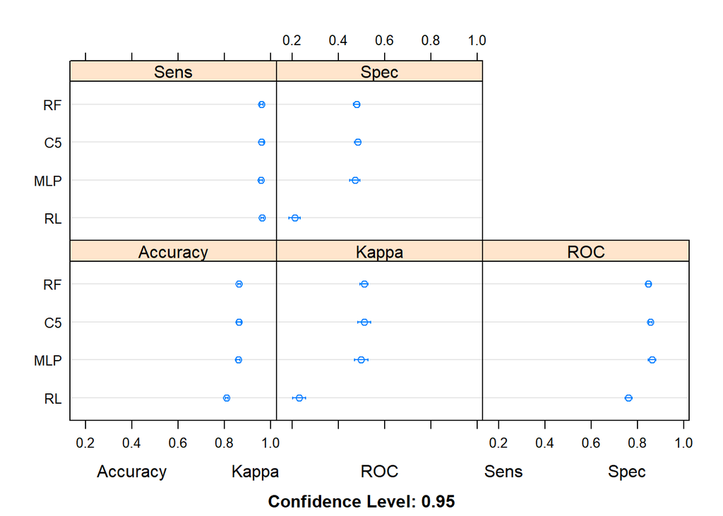

```r
dotplot(comp_modelos)
```

Se hace lo mismo con el grupo balanceado

```r
modelos_bal <- list(RL= rl_train_bal, RF = rf_train_bal,  MLP = nnet_train_bal, C5 = C5_train_bal)
```

```r
comp_modelos_bal <- resamples(modelos_bal)
comp_modelos_bal
```

```
##
## Call:
## resamples.default(x = modelos_bal)
##
## Models: RL, RF, MLP, C5
## Number of resamples: 5
## Performance metrics: Accuracy, Kappa, ROC, Sens, Spec
## Time estimates for: everything, final model fit
```

```r
summary(comp_modelos_bal)
```

```
##
## Call:
## summary.resamples(object = comp_modelos_bal)
##
## Models: RL, RF, MLP, C5
## Number of resamples: 5
##
## Accuracy
##          Min.   1st Qu.    Median      Mean   3rd Qu.      Max. NA's
## RL  0.6886503 0.7029096 0.7039877 0.7035527 0.7070552 0.7151608    0
## RF  0.7611026 0.7622699 0.7730061 0.7706945 0.7748851 0.7822086    0
## MLP 0.7622699 0.7653374 0.7656968 0.7749829 0.7901991 0.7914110    0
## C5  0.7500000 0.7687596 0.7714724 0.7706917 0.7764165 0.7868098    0
##
## Kappa
##          Min.   1st Qu.    Median      Mean   3rd Qu.      Max. NA's
## RL  0.3773006 0.4058736 0.4079755 0.4071268 0.4141104 0.4303737    0
## RF  0.5222623 0.5245399 0.5460123 0.5414006 0.5497713 0.5644172    0
## MLP 0.5245399 0.5306748 0.5314562 0.5499792 0.5804031 0.5828221    0
## C5  0.5000000 0.5375983 0.5429448 0.5414023 0.5528488 0.5736196    0
##
## ROC
##          Min.   1st Qu.    Median      Mean   3rd Qu.      Max. NA's
## RL  0.7448718 0.7616555 0.7658926 0.7661874 0.7700327 0.7884843    0
## RF  0.8305426 0.8436336 0.8577713 0.8514363 0.8602130 0.8650213    0
## MLP 0.8455001 0.8488746 0.8584535 0.8591547 0.8695566 0.8733889    0
## C5  0.8430939 0.8483101 0.8581147 0.8563116 0.8598385 0.8722007    0
##
## Sens
##          Min.   1st Qu.    Median      Mean   3rd Qu.      Max. NA's
## RL  0.6850153 0.6993865 0.7239264 0.7136902 0.7269939 0.7331288    0
## RF  0.7392638 0.7737003 0.7975460 0.7854149 0.8006135 0.8159509    0
## MLP 0.7607362 0.7822086 0.7859327 0.7897019 0.8098160 0.8098160    0
## C5  0.7300613 0.7645260 0.7883436 0.7805126 0.7944785 0.8251534    0
##
## Spec
##          Min.   1st Qu.    Median      Mean   3rd Qu.      Max. NA's
## RL  0.6727829 0.6779141 0.6809816 0.6934523 0.6901840 0.7453988    0
## RF  0.7217125 0.7300613 0.7668712 0.7559989 0.7760736 0.7852761    0
## MLP 0.7217125 0.7423313 0.7699387 0.7602934 0.7730061 0.7944785    0
## C5  0.7125382 0.7546012 0.7699387 0.7609126 0.7791411 0.7883436    0
```

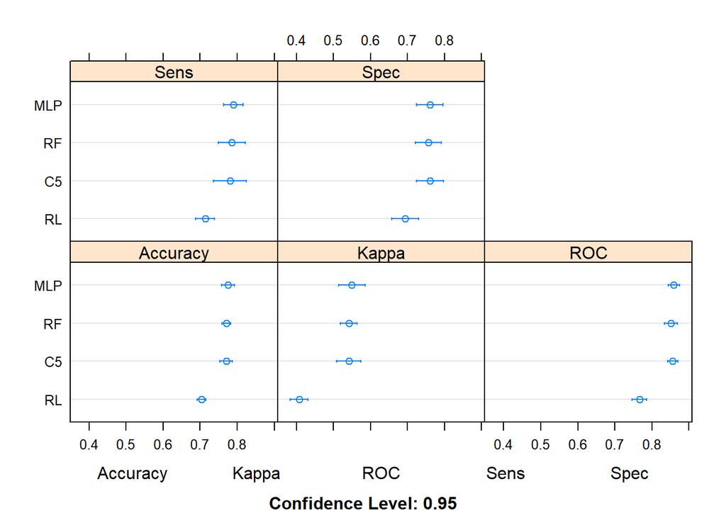

```r
dotplot(comp_modelos_bal)
```

Comportamiento similar de RL (modelo lineal generalizado, base o glm).

En el siguiente contraste, la hipótesis nula es que no existen diferencias entre los modelos (H0: difference = 0). Los elementos por debajo de la diagonal nos da el p-valor. Si dicho p-valor fuera muy bajo (<0.05 si el nivel de confianza elegido es del 95%) se rechazaría la hipótesis nula y los modelos son significativamente diferentes

```r
diferencias <- diff(comp_modelos)
summary(diferencias)
```

```
##
## Call:
## summary.diff.resamples(object = diferencias)
##
## p-value adjustment: bonferroni
## Upper diagonal: estimates of the difference
## Lower diagonal: p-value for H0: difference = 0
##
## Accuracy
##     RL        RF         MLP        C5
## RL            -0.0527438 -0.0492447 -0.0521192
## RF  0.0001900             0.0034991  0.0006246
## MLP 0.0003163 0.9320761             -0.0028745
## C5  0.0007905 1.0000000  0.6162068
##
## Kappa
##     RL        RF         MLP        C5
## RL            -0.2806094 -0.2683402 -0.2812046
## RF  4.166e-05             0.0122692 -0.0005952
## MLP 2.004e-05 0.7908                -0.0128644
## C5  4.392e-05 1.0000     0.2614
##
## ROC
##     RL        RF        MLP       C5
## RL            -0.085854 -0.101307 -0.094674
## RF  0.000112            -0.015452 -0.008819
## MLP 4.006e-05 0.065219             0.006633
## C5  6.104e-05 0.041704  1.000000
##
## Sens
##     RL RF        MLP       C5
## RL      0.002355  0.004710  0.004396
## RF  1             0.002355  0.002041
## MLP 1  1                   -0.000314
## C5  1  1         1
##
## Spec
##     RL        RF        MLP       C5
## RL            -0.267941 -0.259971 -0.272849
## RF  4.079e-05            0.007970 -0.004908
## MLP 1.625e-05 1.0000              -0.012878
## C5  3.504e-05 0.5958    0.2731
```

```r
diferencias_bal <- diff(comp_modelos_bal)
summary(diferencias_bal)
```

```
##
## Call:
## summary.diff.resamples(object = diferencias_bal)
##
## p-value adjustment: bonferroni
## Upper diagonal: estimates of the difference
## Lower diagonal: p-value for H0: difference = 0
##
## Accuracy
##     RL        RF         MLP        C5
## RL            -6.714e-02 -7.143e-02 -6.714e-02
## RF  0.0002606            -4.288e-03  2.819e-06
## MLP 0.0013342 1.0000000              4.291e-03
## C5  0.0002285 1.0000000  1.0000000
##
## Kappa
##     RL        RF         MLP        C5
## RL            -1.343e-01 -1.429e-01 -1.343e-01
## RF  0.0002614            -8.579e-03 -1.702e-06
## MLP 0.0013335 1.0000000              8.577e-03
## C5  0.0002289 1.0000000  1.0000000
##
## ROC
##     RL        RF        MLP       C5
## RL            -0.085249 -0.092967 -0.090124
## RF  0.0006261           -0.007718 -0.004875
## MLP 0.0001947 0.1839350            0.002843
## C5  0.0009992 1.0000000 1.0000000
##
## Sens
##     RL       RF        MLP       C5
## RL           -0.071725 -0.076012 -0.066822
## RF  0.008064           -0.004287  0.004902
## MLP 0.003607 1.000000             0.009189
## C5  0.017844 1.000000  1.000000
##
## Spec
##     RL      RF         MLP        C5
## RL          -0.0625467 -0.0668411 -0.0674603
## RF  0.05720            -0.0042945 -0.0049136
## MLP 0.01743 1.00000               -0.0006191
## C5  0.02235 1.00000    1.00000
```